# R Notebook

```r
library(tidyverse)
library(janitor)
library(infer)
```

# Question 1

We are going to use a dataset on house sales in Ames, Iowa over a number of years. We will be interested in the SalePrice of houses (though we should clean_names() the data, so this will end up as sale_price). Load the data and explore it.

```r
ames <- read_csv("data/ames.csv") %>%
  clean_names()
```

# Question 2

Plot a histogram of sale_price. Is the distribution normal?

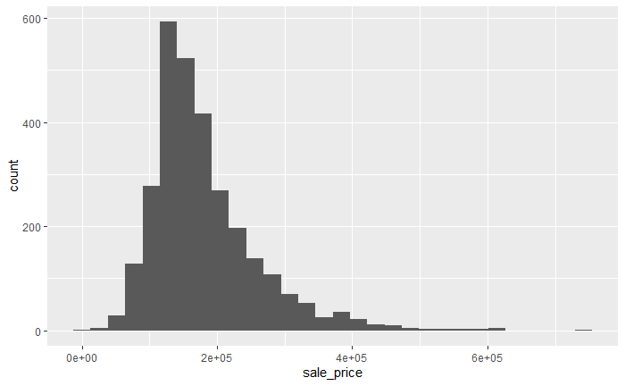

```r
ames %>%
  ggplot(aes(x = sale_price)) +
  geom_histogram()
```

# Question 3

Calculate the population parameter mean of sale_price. Store it in a variable, as we’ll need this value later when we check if each CI contains the parameter value or not.

```r
pop_mean_sale_price <- ames %>%
  summarise(mean_sale_price = mean(sale_price)) %>%
  pull()
```

# Question 4

Now we are going to: - take 1000 random samples each of size 100 from sale_price in ames - create a boostrap sampling distribution of mean(sale_price) from each 100-observation sample (use 1000 reps) - calculate the 95% CI for each bootstrap distribution - store the upper and lower bounds of the CI in a tibble called results

Use the infer workflow to generate the bootstrap distributions and CIs. This code will be pretty hard to write. Think about wrapping the sample creation and infer code in a for loop to generate 1000 random samples and CIs. Create an empty results tibble before the loop, and bind_rows() to it every time you generate a new set of CI bounds.

There’s an outline of the code below, and the full solution below that (if you get stuck). Have a go, but don’t spend too long on this, it’s more important to spend your time thinking about CIs!

```r
results <- tibble()
for (sample_num in 1:1000){

  # get a new 100-observation random sample from ames
  this_sample <- ames %>%
    rep_sample_n(100) %>%
    ungroup() %>%
    select(sale_price)

  # create a bootstrap distribution of mean(sale_price)
  # use 1000 reps
  this_bootstrap <- this_sample %>%
    specify(response = sale_price) %>%
    generate(reps = 1000, type = "bootstrap") %>%
    calculate(stat = "mean")

  # get 95% CI for this_bootstrap distribution
  this_ci <- this_bootstrap %>%
    get_ci(level = 0.95, type = "percentile")

  # prepare new row for results, storing this_ci bounds
  this_result <- c(
    sample_num = sample_num,
    lower = this_ci %>%
      pull(lower_ci),
    upper = this_ci %>%
      pull(upper_ci)
  )

  # add this_result to growing tibble of results
  results <- results %>%
    bind_rows(this_result)
}
```

# Question 5

Pipe results to mutate() to add a new variable popn_param_in_ci which will be TRUE if the population parameter we calculated earlier is between lower and upper, and FALSE otherwise.

```r
results %>%
  mutate(popn_param_in_ci = if_else(pop_mean_sale_price > lower &
                                      pop_mean_sale_price < upper, TRUE, FALSE))
```

| sample_num | lower | upper | popn_param_in_ci |
| --- | --- | --- | --- |
| 1 | 168037.1 | 202503.3 | TRUE |
| 2 | 165458.7 | 196261.7 | TRUE |
| 3 | 166022.3 | 192711.2 | TRUE |
| 4 | 167655.1 | 193383.2 | TRUE |
| 5 | 169677.0 | 205008.5 | TRUE |
| 6 | 163088.7 | 188713.7 | TRUE |
| 7 | 160764.2 | 189035.5 | TRUE |
| 8 | 159356.4 | 195080.1 | TRUE |
| 9 | 157594.7 | 191566.4 | TRUE |
| 10 | 158170.3 | 183747.4 | TRUE |

[output cut: 990 more lines]

```r
NA
```

# Question 6

Perform an appropriate summarise() to determine the proportion of CIs that contain the population parameter. Our confidence level was 95% (equivalent to a proportion of 0.95). Is your proportion close to that value?

[output not shown]

Close enough, %age of values within CI is 94 .8% vs 95% expected.